# Analyzing Individual BGG Users

Phil Henrickson

2022-01-01

# **Bigscotts’s** BoardGameGeek Collection

This notebook contains a set of analyses for the selected user’s boardgamegeek collection. The bulk of the analysis is focused on building a user-specific predictive model to predict the games that Bigscotts is likely to own. This enables to ask questions like, based on the games the user currently owns, what games are a good fit for their collection? What upcoming games are they likely to purchase?

This analysis is based on data from BoardGameGeek that was last updated on **2021-12-20.**

# 1 Collection Overview

We can look at a basic description of the number of games that the user owns, has rated, has previously owned, etc.

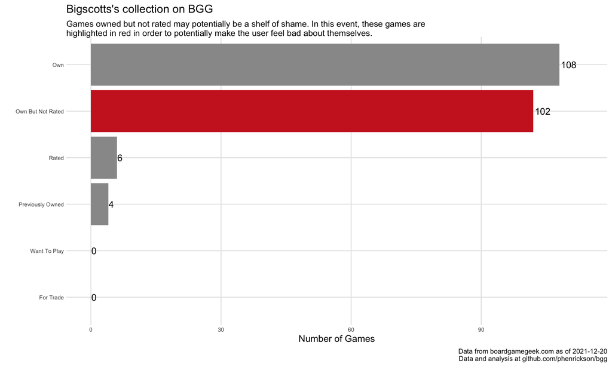

What years has the user owned/rated games from? While we can’t see when a user added or removed a game from their collection, we can look at their collection by the years in which their games were published.

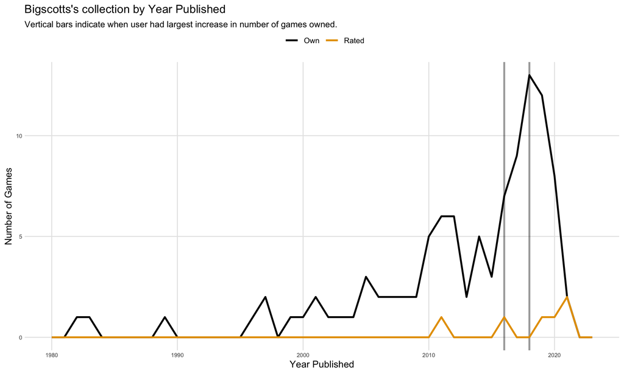

## 1.1 What types of games does Bigscotts own?

We can look at the most frequent types of categories, mechanics, designers, and artists that appear in a user’s collection.

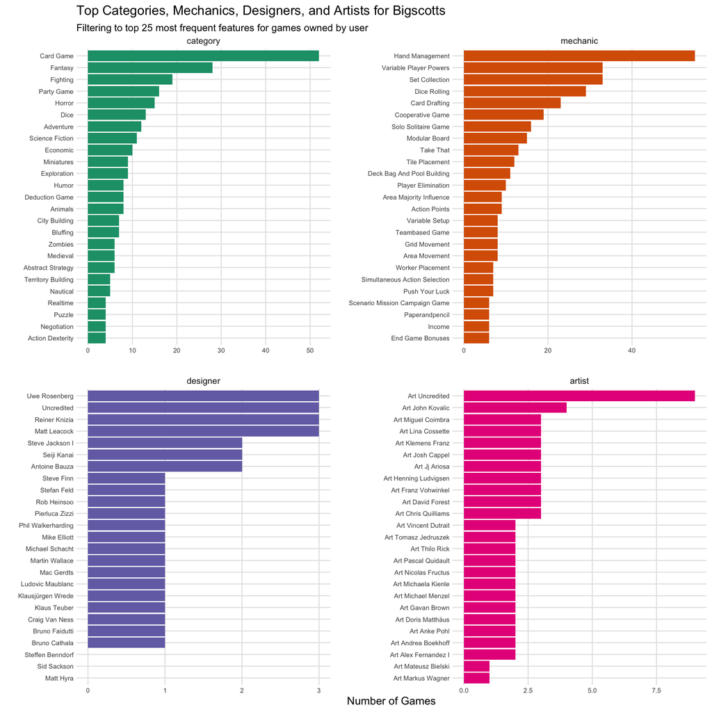

# 2 Modeling **Bigscotts’s** Collection

| username | dataset | period | games_owned | games_rated | games_played |
| --- | --- | --- | --- | --- | --- |
| Bigscotts | training | published before 2020 | 97 | 3 | 100 |
| Bigscotts | test | published 2020 or later | 10 | 3 | 10 |

There are two main (binary) outcomes we will be modeling for the user.

The first, **own** refers to whether the user currently lists a game as owned in their collection. The second, **played** refers to whether the user currently owns, has rated, or previously owned a game. This means the latter will generally have a larger list of games, but may still be a useful category to examine for people who play lots of games without necessarily owning them.

We will train predictive models to learn the probability that the user will own or play individual games based on their features.

## 2.1 Coefficients for Bigscotts

We can examine coefficients from the trained modes, which are penalized logistic regressions fit to our two main outcomes. Positive values indicate that a feature increases a user’s probabilility of owning/rating a game, while negative values indicate a feature decreases the probability.

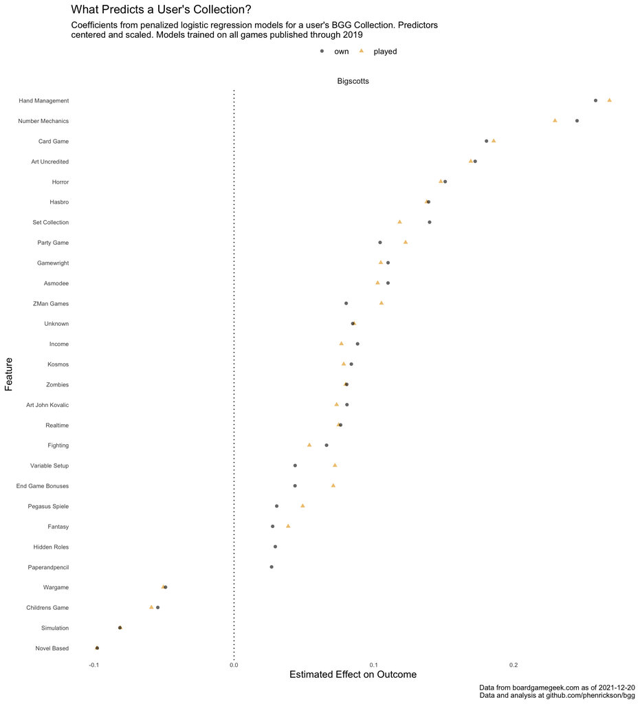

## 2.2 Visualizing Predictors for Bigscotts’s Collection

Why did the model identify these features? We can make density plots of the important features for predicting whether the user owned a game. Blue indicates the density for games owned by the user, while grey indicates the density for games not owned by the user.

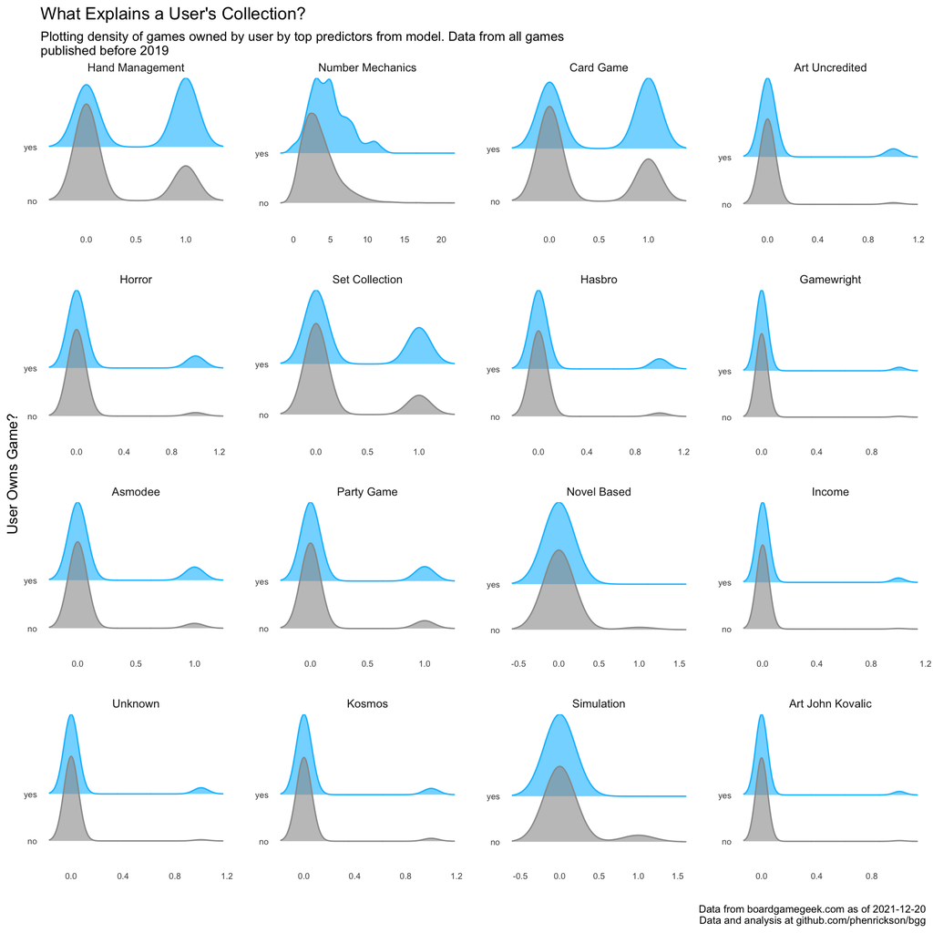

Binary predictors can be difficult to see with this visualization, so we can also directly examine the percentage of games in a user’s collection with a predictor vs the percentage of all games with that predictor.

| username | Feature | % of Games with Feature In_Collection | % of Games with Feature All_Games | Ratio |
| --- | --- | --- | --- | --- |
| Bigscotts | Income | 5.2% | 0.7% | 7.6 |
| Bigscotts | Unknown | 7.2% | 1.4% | 5.0 |
| Bigscotts | Zombies | 6.2% | 1.2% | 5.0 |
| Bigscotts | End Game Bonuses | 6.2% | 1.2% | 5.0 |
| Bigscotts | Gamewright | 4.1% | 0.9% | 4.5 |
| Bigscotts | Realtime | 3.1% | 0.7% | 4.5 |
| Bigscotts | Hidden Roles | 3.1% | 0.7% | 4.4 |
| Bigscotts | Horror | 13.4% | 3.8% | 3.5 |
| Bigscotts | Variable Setup | 6.2% | 1.9% | 3.3 |
| Bigscotts | Hasbro | 11.3% | 3.8% | 3.0 |
| Bigscotts | Asmodee | 14.4% | 5.3% | 2.7 |
| Bigscotts | ZMan Games | 9.3% | 3.5% | 2.7 |
| Bigscotts | Pegasus Spiele | 11.3% | 4.7% | 2.4 |
| Bigscotts | Kosmos | 7.2% | 3.3% | 2.2 |
| Bigscotts | Hand Management | 52.6% | 26.5% | 2.0 |
| Bigscotts | Set Collection | 33.0% | 17.5% | 1.9 |
| Bigscotts | Fighting | 17.5% | 9.0% | 1.9 |
| Bigscotts | Paperandpencil | 5.2% | 2.7% | 1.9 |
| Bigscotts | Party Game | 15.5% | 8.4% | 1.8 |
| Bigscotts | Card Game | 51.5% | 30.8% | 1.7 |
| Bigscotts | Fantasy | 23.7% | 14.7% | 1.6 |
| Bigscotts | Childrens Game | 1.0% | 5.7% | 0.2 |
| Bigscotts | Wargame | 2.1% | 12.6% | 0.2 |
| Bigscotts | Novel Based | 0.0% | 2.9% | 0.0 |
| Bigscotts | Simulation | 0.0% | 8.0% | 0.0 |

# 3 Assess Model’s Performance on Training Set

Before predicting games in upcoming years, we can examine how well the model did and what games it liked in the training set. In this case, we used resampling techniques (cross validation) to ensure that the model had not seen a game before making its predictions.

## 3.1 Separation Plot

An easy way to examine the performance of classification model is to view a separation plot. We plot the predicted probabilities from the model for every game (from resampling) from lowest to highest. We then overlay a blue line for any game that the user does own. A good classifier is one that is able to *separate* the blue (games owned by the user) from the white (games not owned by the user), with most of the blue occurring at the highest probabilities (right side of the chart).

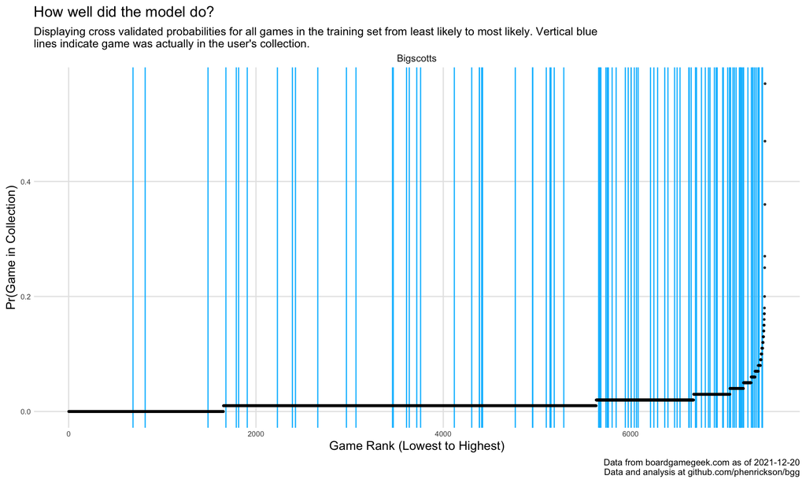

## 3.2 Top Games for **Bigscotts** from Training Set

We can display this information in table form, displaying the 100 games with the highest probability of ownership, adding a blue line when the user does own the game.

| username | yearpublished | game_id | name | pred_played | pred_own | actual_played | actual_own |
| --- | --- | --- | --- | --- | --- | --- | --- |
| Bigscotts | 1959 | 7688 | Memory | 0.28 | 0.57 | 0 | 0 |
| Bigscotts | 1968 | 7262 | Top Trumps | 0.22 | 0.47 | 0 | 0 |
| Bigscotts | 2019 | 276025 | Maracaibo | 0.18 | 0.36 | 0 | 0 |
| Bigscotts | 1959 | 181 | Risk | 0.11 | 0.27 | 0 | 0 |
| Bigscotts | 1948 | 320 | Scrabble | 0.35 | 0.25 | 0 | 0 |
| Bigscotts | 1955 | 1475 | Careers | 0.07 | 0.20 | 0 | 0 |
| Bigscotts | 1980 | 2290 | Good & Bad Ghosts | 0.10 | 0.18 | 0 | 0 |
| Bigscotts | 1900 | 15878 | Rummy | 0.20 | 0.17 | 0 | 0 |
| Bigscotts | 2013 | 133473 | Sushi Go! | 0.18 | 0.17 | 0 | 0 |
| Bigscotts | 1900 | 45 | Perudo | 0.11 | 0.16 | 0 | 0 |
| Bigscotts | 2015 | 180593 | The Bloody Inn | 0.12 | 0.15 | 0 | 0 |
| Bigscotts | 2019 | 266507 | Clank!: Legacy – Acquisitions Incorporated | 0.15 | 0.15 | 0 | 0 |
| Bigscotts | 1933 | 1406 | Monopoly | 0.15 | 0.15 | 0 | 0 |
| Bigscotts | 2013 | 52461 | Legacy: The Testament of Duke de Crecy | 0.09 | 0.14 | 0 | 0 |
| Bigscotts | 2017 | 162886 | Spirit Island | 0.08 | 0.14 | 0 | 0 |
| Bigscotts | 2008 | 40508 | Scrabble Slam! | 0.13 | 0.14 | 0 | 0 |
| Bigscotts | 2019 | 257066 | Sierra West | 0.13 | 0.13 | 0 | 0 |
| Bigscotts | 2000 | 478 | Citadels | 0.16 | 0.13 | 0 | 0 |
| Bigscotts | 2007 | 31808 | GUBS: A Game of Wit and Luck | 0.10 | 0.13 | 0 | 0 |
| Bigscotts | 1988 | 1198 | SET | 0.02 | 0.13 | 0 | 0 |
| Bigscotts | 2016 | 167791 | Terraforming Mars | 0.24 | 0.13 | 0 | 0 |
| Bigscotts | 2018 | 244711 | Newton | 0.30 | 0.12 | 0 | 0 |
| Bigscotts | 2010 | 73171 | Earth Reborn | 0.19 | 0.12 | 0 | 0 |
| Bigscotts | 2017 | 174430 | Gloomhaven | 0.12 | 0.12 | 0 | 0 |
| Bigscotts | 2018 | 205896 | Rising Sun | 0.14 | 0.12 | 0 | 0 |
| Bigscotts | 2009 | 46586 | Ratuki | 0.16 | 0.12 | 0 | 0 |
| Bigscotts | 2010 | 73439 | Troyes | 0.04 | 0.11 | 0 | 0 |
| Bigscotts | 1977 | 811 | Rummikub | 0.06 | 0.11 | 1 | 1 |
| Bigscotts | 2017 | 220308 | Gaia Project | 0.11 | 0.11 | 0 | 0 |
| Bigscotts | 2018 | 247763 | Underwater Cities | 0.13 | 0.11 | 0 | 0 |

[output cut: 70 more lines]

We can also more formally assess how well the model did in resampling by looking at the area under the receiver operating characteristic. A perfect model would receive a score of 1, while a model that cannot predict the outcome will default to a score of 0.5. The extent to which something is a *good* score depends on the setting, but generally anything in the .8 to .9 range is very good while the .7 to .8 range is perfectly acceptable.

| username | outcome_type | .metric | .estimator | .estimate |
| --- | --- | --- | --- | --- |
| Bigscotts | own | roc_auc | binary | 0.759 |
| Bigscotts | played | roc_auc | binary | 0.760 |

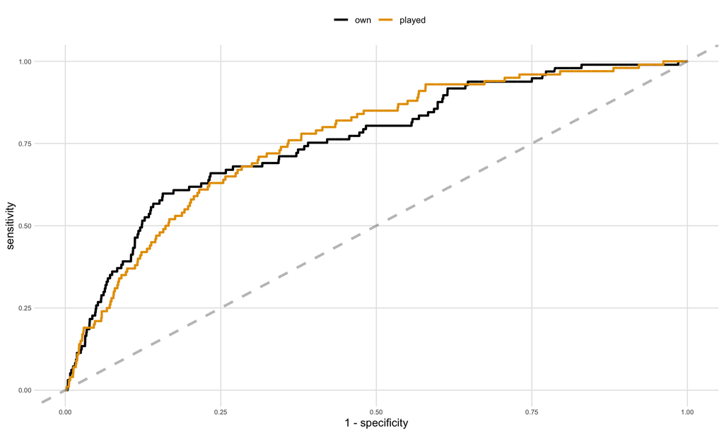

Another way to think about the model performance is to view its lift, or its ability to detect the positive outcomes over that of a null model. High lift indicates the model can much more quickly find all of the positive outcomes (in this case, games owned or played by the user), while a model with no lift is no better than random guessing.

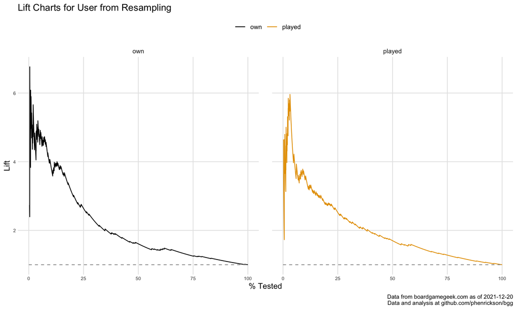

## 3.3 Most and Least Likely Games

What games does the model think Bigscotts is **most likely to own** that are **not** in their collection?

| username | yearpublished | game_id | name | pred_own | actual_own |
| --- | --- | --- | --- | --- | --- |
| Bigscotts | 1959 | 7688 | Memory | 0.57 | 0 |
| Bigscotts | 1968 | 7262 | Top Trumps | 0.47 | 0 |
| Bigscotts | 2019 | 276025 | Maracaibo | 0.36 | 0 |
| Bigscotts | 1959 | 181 | Risk | 0.27 | 0 |
| Bigscotts | 1948 | 320 | Scrabble | 0.25 | 0 |

What games does the model think Bigscotts is **least likely to own** that **are** in their collection?

| username | yearpublished | game_id | name | pred_own | actual_own |
| --- | --- | --- | --- | --- | --- |
| Bigscotts | 2010 | 66608 | Two by Two | 0.00 | 1 |
| Bigscotts | 2006 | 24002 | Pirate King | 0.00 | 1 |
| Bigscotts | 2017 | 210290 | Legendary: Buffy The Vampire Slayer | 0.00 | 1 |
| Bigscotts | 2019 | 257518 | Claustrophobia 1643 | 0.01 | 1 |
| Bigscotts | 2011 | 83068 | 1955: The War of Espionage | 0.01 | 1 |

## 3.4 Top Games by Year

Top 25 games most likely to be owned by the user in each year, highlighting in blue the games that the user has owned/played.

| rank | 2011 | 2012 | 2013 | 2014 | 2015 | 2016 | 2017 | 2018 | 2019 |
| --- | --- | --- | --- | --- | --- | --- | --- | --- | --- |
| 1 | Nightfall | Zombicide | Sushi Go! | Ultimate Werewolf | The Bloody Inn | Terraforming Mars | Spirit Island | Newton | Maracaibo |
| 2 | Munchkin Zombies | Terra Mystica | Legacy: The Testament of Duke de Crecy | Dead of Winter: A Crossroads Game | Blood Rage | Bloodborne: The Card Game | Gloomhaven | Rising Sun | Clank!: Legacy – Acquisitions Incorporated |
| 3 | Resident Evil Deck Building Game: Alliance | Smash Up | Room 25 | Onirim (Second Edition) | Risk: Europe | Sushi Go Party! | Gaia Project | Underwater Cities | Sierra West |
| 4 | The Walking Dead: The Board Game | Monopoly Millionaire | Zombicide Season 2: Prison Outbreak | One Night Ultimate Werewolf | Zombicide Season 3: Rue Morgue | Dead of Winter: The Long Night | Trash Pandas | Zombicide: Green Horde | Barrage |
| 5 | Mage Knight Board Game | Munchkin Apocalypse | Prosperity | Fields of Arle | Bring Your Own Book | Inis | Twin It! | Boomerang | Shardhunters |
| 6 | Eaten by Zombies! | Coup | Huida de Silver City | Legendary Encounters: An Alien Deck Building Game | Salem 1692 | Citadels | Unfair | Street Masters | It's a Wonderful World |
| 7 | Nightfall: Martial Law | Love Letter | Munchkin Pathfinder | Saint Petersburg (Second Edition) | Mysterium | Trivial Pursuit: Classic Edition | Photosynthesis | 5-Minute Marvel | Tapestry |
| 8 | Mansions of Madness | Nightfall: The Coldest War | Munchkin Legends | Akrotiri | Exploding Kittens: NSFW Deck | Smash Up: It's Your Fault! | Ex Libris | The Walking Dead: No Sanctuary | The Isle of Cats |
| 9 | Ninjato | Targi | Forbidden Desert | Ancient Terrible Things | Unspeakable Words: Deluxe Edition | Pandemic: Reign of Cthulhu | Arkham Noir: Case #1 – The Witch Cult Murders | Valhalla | Tainted Grail: The Fall of Avalon |
| 10 | The Walking Dead Board Game | Robinson Crusoe: Adventures on the Cursed Island | Smash Up: Awesome Level 9000 | Dragon's Hoard | Munchkin Oz | Mansions of Madness: Second Edition | After The Virus | Pandemic: Fall of Rome | Amul |
| 11 | Cthulhu Gloom | Kill the Overlord | Cube Quest | Run, Fight, or Die! | Sylvion | Hit Z Road | Apocrypha Adventure Card Game: Box One – The World | Haven | Terrors of London |
| 12 | A Few Acres of Snow | One Night Werewolf | A Study in Emerald | Diner | Smash Up: Munchkin | Capital Lux | 5-Minute Dungeon | Duelosaur Island | Era: Medieval Age |
| 13 | Ascension: Return of the Fallen | Munchkin Conan | Lewis & Clark: The Expedition | Ultimate Werewolf: Deluxe Edition | Arboretum | Pathfinder Adventure Card Game: Mummy's Mask – Base Set | Paper Tales | Brass: Birmingham | Ragusa |
| 14 | Dungeon Petz | Last Night on Earth: Timber Peak | Pathfinder Adventure Card Game: Rise of the Runelords – Base Set | Good Cop Bad Cop | Qwirkle Cards | Mistfall: Heart of the Mists | Breaking Bad: The Board Game | Shadows: Amsterdam | The Magnificent |
| 15 | Cave Evil | Space Cadets | Impulse | Deception: Murder in Hong Kong | The Voyages of Marco Polo | Black Orchestra | Massive Darkness | Metro X | Last Bastion |
| 16 | Spectral Rails | Wiz-War (Eighth Edition) | Invaders | Student Bodies | Bang! The Dice Game: The Walking Dead | Pandemic: Iberia | One Night Ultimate Alien | Renegade | Dragonrealm |
| 17 | The Ares Project | Miskatonic School for Girls | Smash Up: The Obligatory Cthulhu Set | Sheriff of Nottingham | Nevermore | Aeon's End | The Godfather: Corleone's Empire | Nemesis | Paranormal Detectives |
| 18 | PAX | Resident Evil Deck Building Game: Mercenaries | City of Remnants | Smash Up: Science Fiction Double Feature | Exploding Kittens | Clank!: A Deck-Building Adventure | Century: Spice Road | Darkest Night (Second Edition) | Pathfinder Adventure Card Game: Core Set |
| 19 | Terra Evolution | Uncharted: The Board Game | The Walking Dead Board Game: The Best Defense | Smash Up: Monster Smash | Epic Card Game | Great Western Trail | Smash Up: What Were We Thinking? | Tiny Epic Zombies | Middara: Unintentional Malum – Act 1 |
| 20 | Ascension: Storm of Souls | Libertalia | Tash-Kalar: Arena of Legends | Imperial Settlers | 504 | Pocket Madness | InBetween | Critical Mass: Patriot vs Iron Curtain | Machina Arcana (Second/Third Edition) |
| 21 | The Metagame | Descent: Journeys in the Dark (Second Edition) | UGO! | Castles of Mad King Ludwig | Through the Ages: A New Story of Civilization | Captain Sonar | Fate of the Elder Gods | Kero | Cover Your Kingdom |
| 22 | Dungeon Fighter | Lords of Waterdeep | Zpocalypse | Abyss | Dragonwood | Dawn of the Zeds (Third Edition) | Carthago: Merchants & Guilds | Palm Island | Zombicide: Invader |
| 23 | Mundus Novus | Escape: The Curse of the Temple | LEADERS: The Combined Strategy Game | Assault on Doomrock | One Night Ultimate Werewolf: Daybreak | Heir to the Pharaoh | XenoShyft: Dreadmire | Arkham Noir: Case #2 – Called Forth By Thunder | Zombicide: Dark Side |
| 24 | Skull | Neuroshima: Convoy | Dark Darker Darkest | Red7 | One Night Ultimate Vampire | Smash Up: Cease and Desist | Pandemic Legacy: Season 2 | Lords of Hellas | Tiny Towns |
| 25 | Tem-Purr-A | Morels | Dungeon Twister: The Card Game | La Granja | A Study in Emerald (Second Edition) | Exceed Fighting System | Azul | Root | Unlock!: Epic Adventures |

## 3.5 Interactive Predictions from Resampling

Interactive table for predictions from resampling.

|  | username | yearpublished | rank | game_id | name | pred_played | pred_own | actual_played | actual_own |
| --- | --- | --- | --- | --- | --- | --- | --- | --- | --- |
| 1 | Bigscotts | 1900 | 8 | 15878 | Rummy | 0.2 | 0.17 | 0 | 0 |
| 2 | Bigscotts | 1900 | 10 | 45 | Perudo | 0.11 | 0.16 | 0 | 0 |
| 3 | Bigscotts | 1900 | 41 | 4792 | Tiddledy Winks | 0.07 | 0.1 | 0 | 0 |
| 4 | Bigscotts | 1900 | 99 | 11670 | The Game of Authors | 0.11 | 0.07 | 0 | 0 |
| 5 | Bigscotts | 1900 | 150 | 171 | Chess | 0.1 | 0.05 | 0 | 0 |
| 6 | Bigscotts | 1900 | 211 | 2136 | Pachisi | 0.06 | 0.05 | 0 | 0 |
| 7 | Bigscotts | 1900 | 214 | 1115 | Poker | 0.06 | 0.05 | 0 | 0 |
| 8 | Bigscotts | 1900 | 241 | 2389 | Othello | 0.03 | 0.04 | 0 | 0 |
| 9 | Bigscotts | 1900 | 245 | 2448 | Kalah | 0.04 | 0.04 | 0 | 0 |
| 10 | Bigscotts | 1900 | 279 | 9851 | Shut the Box | 0.08 | 0.04 | 0 | 0 |

[output cut: 7426 more lines]

# 4 Validating the Model on 2020

How well did a model trained on a user’s collection through 2019 perform in predicting games for the user from 2020?

| username | outcome_type | yearpublished | .metric | .estimator | .estimate |
| --- | --- | --- | --- | --- | --- |
| Bigscotts | own | 2020 | roc_auc | binary | 0.655 |
| Bigscotts | played | 2020 | roc_auc | binary | 0.643 |

Table of top 25 games from 2020, highlighting games that the user owns.

| username | yearpublished | game_id | name | pred_own | pred_played | actual_own | actual_played |
| --- | --- | --- | --- | --- | --- | --- | --- |
| Bigscotts | 2020 | 256317 | Guild Master | 0.21 | 0.23 | 0 | 0 |
| Bigscotts | 2020 | 184267 | On Mars | 0.19 | 0.17 | 0 | 0 |
| Bigscotts | 2020 | 295687 | Trust Me, I'm a Doctor | 0.14 | 0.15 | 0 | 0 |
| Bigscotts | 2020 | 291457 | Gloomhaven: Jaws of the Lion | 0.09 | 0.08 | 0 | 0 |
| Bigscotts | 2020 | 300322 | Hallertau | 0.09 | 0.09 | 0 | 0 |
| Bigscotts | 2020 | 320819 | Dinner in Paris | 0.09 | 0.09 | 0 | 0 |
| Bigscotts | 2020 | 292333 | Cowboys II: Cowboys & Indians Edition | 0.07 | 0.07 | 0 | 0 |
| Bigscotts | 2020 | 295577 | Dungeon Mayhem: Monster Madness | 0.06 | 0.06 | 0 | 0 |
| Bigscotts | 2020 | 308765 | Praga Caput Regni | 0.06 | 0.07 | 0 | 0 |
| Bigscotts | 2020 | 262208 | Dungeon Drop | 0.05 | 0.05 | 0 | 0 |
| Bigscotts | 2020 | 276654 | 7 Souls | 0.05 | 0.05 | 0 | 0 |
| Bigscotts | 2020 | 299252 | Here to Slay | 0.05 | 0.05 | 0 | 0 |
| Bigscotts | 2020 | 302310 | Nanaki | 0.05 | 0.07 | 0 | 0 |
| Bigscotts | 2020 | 304285 | Infinity Gauntlet: A Love Letter Game | 0.05 | 0.05 | 0 | 0 |
| Bigscotts | 2020 | 306481 | Tawantinsuyu: The Inca Empire | 0.05 | 0.05 | 0 | 0 |
| Bigscotts | 2020 | 314040 | Pandemic Legacy: Season 0 | 0.05 | 0.05 | 0 | 0 |
| Bigscotts | 2020 | 316377 | 7 Wonders (Second Edition) | 0.05 | 0.05 | 0 | 0 |
| Bigscotts | 2020 | 236861 | Full Moon Jacket | 0.04 | 0.04 | 0 | 0 |
| Bigscotts | 2020 | 245659 | Vampire: The Masquerade – Vendetta | 0.04 | 0.04 | 0 | 0 |
| Bigscotts | 2020 | 246900 | Eclipse: Second Dawn for the Galaxy | 0.04 | 0.03 | 0 | 0 |
| Bigscotts | 2020 | 282081 | The Zorro Dice Game | 0.04 | 0.05 | 0 | 0 |
| Bigscotts | 2020 | 293556 | Gloomy Graves | 0.04 | 0.04 | 0 | 0 |
| Bigscotts | 2020 | 294484 | Unmatched: Cobble & Fog | 0.04 | 0.04 | 0 | 0 |
| Bigscotts | 2020 | 296151 | Viscounts of the West Kingdom | 0.04 | 0.05 | 0 | 0 |
| Bigscotts | 2020 | 297030 | Tekhenu: Obelisk of the Sun | 0.04 | 0.03 | 0 | 0 |

# 5 Predicting Upcoming Games (2020 and On) for **Bigscotts**

Examine the top games for the test set.

| username | yearpublished | game_id | name | rank | own | played |
| --- | --- | --- | --- | --- | --- | --- |
| Bigscotts | 2020 | 256317 | Guild Master | 1 | 0.21 | 0.23 |
| Bigscotts | 2020 | 184267 | On Mars | 2 | 0.19 | 0.17 |
| Bigscotts | 2020 | 295687 | Trust Me, I'm a Doctor | 3 | 0.14 | 0.15 |
| Bigscotts | 2020 | 300322 | Hallertau | 4 | 0.09 | 0.09 |
| Bigscotts | 2020 | 291457 | Gloomhaven: Jaws of the Lion | 5 | 0.09 | 0.08 |
| Bigscotts | 2020 | 320819 | Dinner in Paris | 6 | 0.09 | 0.09 |
| Bigscotts | 2020 | 292333 | Cowboys II: Cowboys & Indians Edition | 7 | 0.07 | 0.07 |
| Bigscotts | 2020 | 308765 | Praga Caput Regni | 8 | 0.06 | 0.07 |
| Bigscotts | 2020 | 295577 | Dungeon Mayhem: Monster Madness | 9 | 0.06 | 0.06 |
| Bigscotts | 2020 | 306481 | Tawantinsuyu: The Inca Empire | 10 | 0.05 | 0.05 |
| Bigscotts | 2020 | 276654 | 7 Souls | 11 | 0.05 | 0.05 |
| Bigscotts | 2020 | 304285 | Infinity Gauntlet: A Love Letter Game | 12 | 0.05 | 0.05 |
| Bigscotts | 2020 | 262208 | Dungeon Drop | 13 | 0.05 | 0.05 |
| Bigscotts | 2020 | 314040 | Pandemic Legacy: Season 0 | 14 | 0.05 | 0.05 |
| Bigscotts | 2020 | 316377 | 7 Wonders (Second Edition) | 15 | 0.05 | 0.05 |
| Bigscotts | 2020 | 302310 | Nanaki | 16 | 0.05 | 0.07 |
| Bigscotts | 2020 | 299252 | Here to Slay | 17 | 0.05 | 0.05 |
| Bigscotts | 2020 | 299179 | Chancellorsville 1863 | 18 | 0.04 | 0.04 |
| Bigscotts | 2020 | 318098 | Silver Dagger | 19 | 0.04 | 0.04 |
| Bigscotts | 2020 | 325611 | Runes of Zun | 20 | 0.04 | 0.04 |
| Bigscotts | 2020 | 296151 | Viscounts of the West Kingdom | 21 | 0.04 | 0.05 |
| Bigscotts | 2020 | 297030 | Tekhenu: Obelisk of the Sun | 22 | 0.04 | 0.03 |
| Bigscotts | 2020 | 315196 | Dungeons & Dragons: Adventure Begins | 23 | 0.04 | 0.04 |
| Bigscotts | 2020 | 245659 | Vampire: The Masquerade – Vendetta | 24 | 0.04 | 0.04 |
| Bigscotts | 2020 | 327797 | Monopoly Bid | 25 | 0.04 | 0.04 |
| Bigscotts | 2021 | 342942 | Ark Nova | 1 | 0.15 | 0.18 |
| Bigscotts | 2021 | 310873 | Carnegie | 2 | 0.09 | 0.10 |
| Bigscotts | 2021 | 290618 | Wishland | 3 | 0.08 | 0.09 |
| Bigscotts | 2021 | 343905 | Boonlake | 4 | 0.08 | 0.10 |
| Bigscotts | 2021 | 291859 | Riftforce | 5 | 0.08 | 0.09 |
| Bigscotts | 2021 | 280984 | Ruins: Death Binder | 6 | 0.07 | 0.07 |
| Bigscotts | 2021 | 335764 | Unmatched: Battle of Legends, Volume Two | 7 | 0.07 | 0.07 |
| Bigscotts | 2021 | 313085 | Sleep Tight | 8 | 0.06 | 0.06 |
| Bigscotts | 2021 | 295785 | Euthia: Torment of Resurrection | 9 | 0.05 | 0.05 |
| Bigscotts | 2021 | 290236 | Canvas | 10 | 0.05 | 0.04 |
| Bigscotts | 2021 | 275802 | Carnival Zombie: 2nd Edition | 11 | 0.05 | 0.04 |
| Bigscotts | 2021 | 318184 | Imperium: Classics | 12 | 0.05 | 0.07 |
| Bigscotts | 2021 | 342848 | World of Warcraft: Wrath of the Lich King | 13 | 0.05 | 0.05 |
| Bigscotts | 2021 | 319793 | Happy City | 14 | 0.05 | 0.05 |
| Bigscotts | 2021 | 328569 | Mint Bid | 15 | 0.05 | 0.04 |
| Bigscotts | 2021 | 273330 | Bloodborne: The Board Game | 16 | 0.05 | 0.05 |
| Bigscotts | 2021 | 328871 | Terraforming Mars: Ares Expedition | 17 | 0.05 | 0.05 |
| Bigscotts | 2021 | 277565 | Ashes to Ashes | 18 | 0.05 | 0.05 |
| Bigscotts | 2021 | 291847 | Mantis Falls | 19 | 0.05 | 0.05 |
| Bigscotts | 2021 | 341169 | Great Western Trail (Second Edition) | 20 | 0.04 | 0.04 |
| Bigscotts | 2021 | 286751 | Zombicide: 2nd Edition | 21 | 0.04 | 0.03 |
| Bigscotts | 2021 | 333553 | For the King (and Me) | 22 | 0.04 | 0.03 |
| Bigscotts | 2021 | 320446 | Corduba 27 a.C. | 23 | 0.04 | 0.04 |
| Bigscotts | 2021 | 316287 | Quest | 24 | 0.04 | 0.04 |
| Bigscotts | 2021 | 277659 | Final Girl | 25 | 0.04 | 0.04 |
| Bigscotts | 2022 | 295895 | Distilled | 1 | 0.07 | 0.06 |
| Bigscotts | 2022 | 283137 | Human Punishment: The Beginning | 2 | 0.06 | 0.05 |
| Bigscotts | 2022 | 342246 | Feuding Foodies | 3 | 0.05 | 0.05 |
| Bigscotts | 2022 | 295770 | Frosthaven | 4 | 0.05 | 0.05 |
| Bigscotts | 2022 | 331106 | The Witcher: Old World | 5 | 0.05 | 0.06 |
| Bigscotts | 2022 | 317511 | Tindaya | 6 | 0.05 | 0.07 |
| Bigscotts | 2022 | 277025 | Vampire: The Masquerade – CHAPTERS | 7 | 0.04 | 0.03 |
| Bigscotts | 2022 | 273814 | Deliverance | 8 | 0.04 | 0.04 |
| Bigscotts | 2022 | 320718 | Hidden Leaders | 9 | 0.04 | 0.04 |
| Bigscotts | 2022 | 280726 | Legacies | 10 | 0.04 | 0.05 |
| Bigscotts | 2022 | 281549 | Beast | 11 | 0.04 | 0.04 |
| Bigscotts | 2022 | 281258 | Sub Terra II: Inferno's Edge | 12 | 0.03 | 0.03 |
| Bigscotts | 2022 | 240980 | Blood on the Clocktower | 13 | 0.03 | 0.03 |
| Bigscotts | 2022 | 336986 | Flamecraft | 14 | 0.03 | 0.04 |
| Bigscotts | 2022 | 284842 | So, You've Been Eaten | 15 | 0.03 | 0.03 |
| Bigscotts | 2022 | 322524 | Bardsung | 16 | 0.03 | 0.03 |
| Bigscotts | 2022 | 293941 | Mage Noir | 17 | 0.03 | 0.03 |
| Bigscotts | 2022 | 339592 | Sheep in Disguise | 18 | 0.03 | 0.03 |
| Bigscotts | 2022 | 340325 | Vagrantsong | 19 | 0.03 | 0.04 |
| Bigscotts | 2022 | 334065 | Verdant | 20 | 0.03 | 0.03 |
| Bigscotts | 2022 | 305096 | Endless Winter: Paleoamericans | 21 | 0.03 | 0.04 |
| Bigscotts | 2022 | 303731 | Primal: The Awakening | 22 | 0.02 | 0.02 |
| Bigscotts | 2022 | 322289 | Darwin's Journey | 23 | 0.02 | 0.02 |
| Bigscotts | 2022 | 343900 | Senjutsu: Battle For Japan | 24 | 0.02 | 0.02 |
| Bigscotts | 2022 | 271601 | Feed the Kraken | 25 | 0.02 | 0.02 |

## 5.1 Interactive Table for Upcoming Games 2020 and On

|  | username | yearpublished | game_id | name | rank | own | played |
| --- | --- | --- | --- | --- | --- | --- | --- |
| 1 | Bigscotts | 2020 | 256317 | Guild Master | 1 | 0.21 | 0.23 |
| 2 | Bigscotts | 2020 | 184267 | On Mars | 2 | 0.19 | 0.17 |
| 3 | Bigscotts | 2021 | 342942 | Ark Nova | 3 | 0.15 | 0.18 |
| 4 | Bigscotts | 2020 | 295687 | Trust Me, I'm a Doctor | 4 | 0.14 | 0.15 |
| 5 | Bigscotts | 2020 | 300322 | Hallertau | 5 | 0.09 | 0.09 |
| 6 | Bigscotts | 2020 | 291457 | Gloomhaven: Jaws of the Lion | 6 | 0.09 | 0.08 |
| 7 | Bigscotts | 2020 | 320819 | Dinner in Paris | 7 | 0.09 | 0.09 |
| 8 | Bigscotts | 2021 | 310873 | Carnegie | 8 | 0.09 | 0.1 |
| 9 | Bigscotts | 2021 | 290618 | Wishland | 9 | 0.08 | 0.09 |
| 10 | Bigscotts | 2021 | 343905 | Boonlake | 10 | 0.08 | 0.1 |

[output cut: 1627 more lines]